# Investigate the sources of error in spaceborne LiDAR measurements and establish a framework for obtaining near-coincident, comparable GEDI measurements for vegetation structure change analysis

## Main idea

- There is a lot of challenges for before and after disturbance comparisons using GEDI data (East et al. 2023; Mandl et al. 2023; Huettermann et al. 2023).

**Hypothesis:** If comparability is compromised due to errors associated to specific covariates (e.g. Topography, Land Cover, Tree species), then a method could be developed to mitigate those errors and make pairs more comparable.

**Proposed outcome:** A systematic way to get comparable GEDI metrics which takes into account errors associated to topographic, landscape and vegatation covariates.

## Literature review

### Questions that I want to answer:

- What methods have been used to obtain comparable space-borne LiDAR measurements?
- What are the main challenges and best practices in comparing measurements from GEDI, ICESat-2, or other space-borne LiDAR datasets and how do researchers deal with them?
- What pre-processing techniques (e.g. filtering, interpolation) have been used?
- How can accurate comparability be assessed?

#### *Methods used to obtain comparable GEDI measurements*

Holcomb et al. (2024) developed a method to examine forest changes using nearby GEDI footprints. These nearby GEDI footprints were chosen using a 40 meter threshold. They showed that GEDI is able to capture biomass/canopy height losses after disturbances in a 30x30m resolution and at a population level.

Different approaches not using spatially coincident pairs have also been considered before. For instance, to study the effects of fires in Portugal and Spain, Guerra-Hernández et al. (2024) aggregated GEDI footpints overlapping the burned area, before and after the fire occured. With this they estimated the average AGBD loss caused by the fire.

#### *Main challenges while comparing space-borne LiDAR data*

Factors that can lead to systematic biases in canopy height estimations, complicating comparisons:

##### Geo-location errors

GEDI footprints have a geo-location error of approximately 10.2 m. Low geolocation accuracy can cause errors on the calculation of ground elevation. Moreover, on heterogenous canopies, geolocation error can cause the measurement to be taken over a different part of the canopy than the one presented.

Big improvements related to geolocation error have taken place passing from GEDI v1 to v2 (Pronk, Eleveld, and Ledoux 2024). Additionally, researchers have also worked on improving the geolocation accuracy using high-res DEMs (Schleich et al. 2023).

##### Terrain slope

The terrain slope significantly affects spaceborne LiDAR measurements. On sloped terrain, laser pulses reflect from both vegetation and the ground simultaneously, leading to overlapping signals and complicating the separation of canopy and ground returns (Ji et al. 2024). The maximum error for rh estimation associated to sloped terrains can be modeled as $max(\epsilon) = \frac{1}{2}*D*tan(slope)$ and is presented on Figure 1.

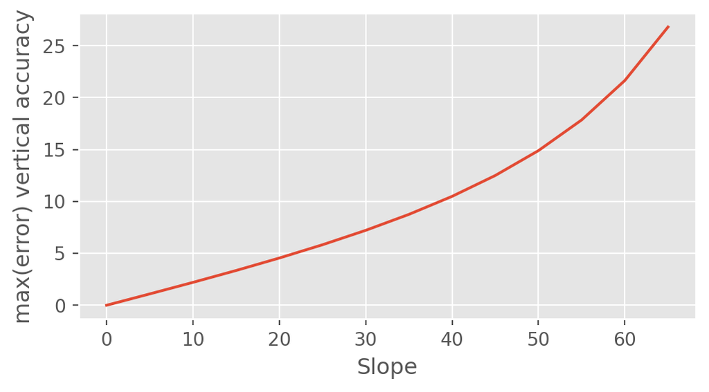

Figure 1: Error on vertical accuracy

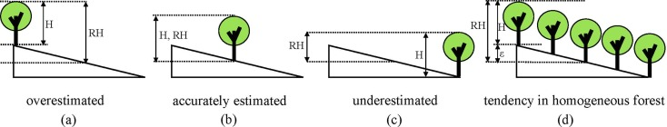

Figure 2: Effect of slope on canopy height estimation. Taken from Ji et al. (2024)

##### Temporal resolution

When actual pairs are found, another big challenge is to evaluate if these pairs can be comparable based on what has happened during the time between shots. East et al. (2023) found for instance that structural changes vary as a function of time after disturbance (Initially seen on lower layers, then on upper canopy).

The time between GEDI pairs used for the study on the amazon rainforest range from 5 to 1422 dyas with an average of time between shots of 522 days.

##### Land cover

For the specific case of ground elevation, Urbazaev et al. (2022) assessed the effects of different landcovers on the accuracy of GEDI and ICESat’s estimations. They found that mean errors were less than 1m for all LC except for tropical forests where errors ranged from 1.75 to 5.56 meters.

In forests with dense, multi-layered canopies, the GEDI laser pulse might be intercepted by upper canopy elements, preventing it from reaching the ground. This can lead to an overestimation of canopy height or an inaccurate ground elevation reading, affecting the overall height calculation.

An initial experiment was performed using pairs of GEDI measurements that overlap with MODIS BA on different types of land cover. The results are shown on Figure 3.

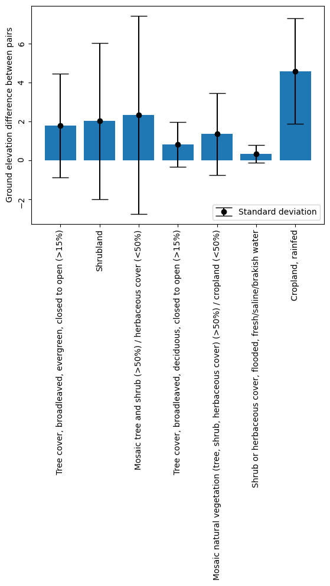

Figure 3: Difference beween pairs of GEDI shots on different land covers where fires have occured.

##### Seasonality

Moreover, LiDAR data collected in leaf-on and leaf-off conditions can vary due to seasonal changes in canopy structure and density. Few studies have explored how using GEDI data from different seasons affects forest height estimation. M. Chen et al. (2023) showed seasonal variations on gedi RH98 measurements. Nevertheless, these variations were attributed to differing GEDI locations rather than seasonality.

#### *Preprocessing techniques for spaceborne LiDAR pair handling*

##### Filtering techniques

Holcomb et al. (2024) applied several filtering stpes to the GEDI data used on their study. The main ones are described in the table below:

Filters used by Holcomb et al. (2024)

| **Filtering Step** | **Description** |
| --- | --- |
| **Removal of low-quality shots** | GEDI shots flagged as low quality by NASA were discarded to retain only reliable measurements. |
| **Exclusion of periods with high geolocation error** | Data collected during periods of above-average geolocation error were excluded (GEDI v2 error: 10.2 m). |
| **Filtering based on beam sensitivity** | Shots with insufficient sensitivity to penetrate the canopy were removed (sensitivity > 0.98 required). |
| **Exclusion of non-forest areas** | Shots over water or urban areas were filtered out, as GEDI is designed to study vegetation structure. |
| **Comparison with TanDEM-X elevation data** | Shots with large discrepancies between GEDI and TanDEM-X elevation estimates were excluded. |

Pronk, Eleveld, and Ledoux (2024) filters were:

Filters used by Pronk, Eleveld, and Ledoux (2024)

| **Filtering Flag** | **Condition** | **Description** |
| --- | --- | --- |
| **rx_assess_quality_flag** | Non-zero | Excludes shots with low overall signal quality. |
| **surface_flag** | Non-zero | Ensures a ground surface return was detected. |
| **degrade_flag** | Zero | Includes only shots where the data was not degraded. |

Finally, Milenković et al. (2022) followed the steps presented on the table below:

Filters used by Milenković et al. (2022)

| **Step** | **Substep** | **Description** |
| --- | --- | --- |
| **Initial Data Selection** |  | Started with GEDI Level 2A v2 data collected over six months, containing ~10.9 million geolocated footprints. |
| **Pre-processing Filters** |  | Applied two main filters to clean the initial dataset: |
|  | **Secondary Forest Filter** | Selected only GEDI shots overlapping with secondary forest pixels (stand age > 0) in Rondônia state. |
|  | **Erroneous Forest Height Filter** | Excluded shots with RH98 values < 0 or > 75 m to remove implausible height measurements. |
| **Stratification into Subgroups** |  | Split the remaining shots into subgroups based on acquisition parameters: |
|  | **Quality and Degradation Flags** | Created subgroups (e.g., QS90) including only shots with quality flag = 1 and degradation flag = 0. |
|  | **Beam Sensitivity Thresholds** | QS90 was divided into QS95, QS98, and QS99 based on sensitivity thresholds (0.95, 0.98, 0.99). |
|  | **Algorithm Setting Group for Sensitivity** | Formed subgroups (e.g., ALL-S2, QS90-S2) using RH98 values but with sensitivity from Algorithm Setting Group 2. |

##### Ground and canopy height correction

Methods to improve the comparability of space-borne LiDAR pairs have been developed recently (Specifically, these methods could improve the vertical accuracy of GEDI). Ji et al. (2024) used overlapping pairs of GEDI and ICE-Sat to improve the calculation of ground elevation and thus ameliorate the canopy height calculations. These overlapping pairs were then used to assess their capability to detect deforestation in Brazil. The steps followed are described on Figure 4, Table 1 and Table 2.

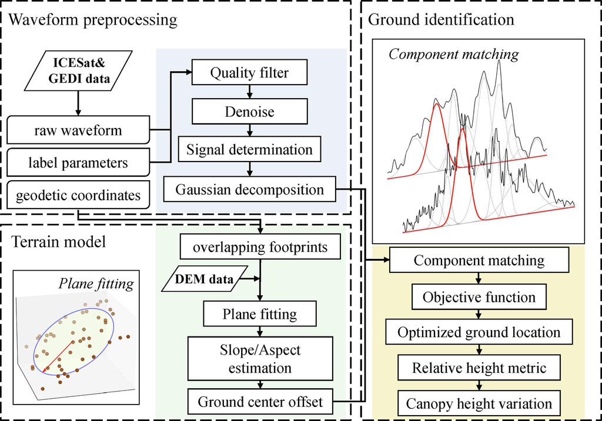

Figure 4: Graphical description of Ji et al. (2024) pre-processing techniques

Table 1: Pre-processing for Improved Ground Identification

| **Step** | **Description** |
| --- | --- |
| **Noise Removal and Signal Range Definition** | Raw waveform data from ICESat/GLAS and GEDI is processed to eliminate noise using a Gaussian filter and a signal range threshold above the noise level. |
| **Waveform Decomposition** | The valid signal range is decomposed into multiple Gaussian components using the Progressive Waveform Decomposition (PWD) algorithm, representing layers like canopy or ground. |
| **Initial Ground Return Selection** | For overlapping footprints (centers within 50m), Gaussian components are shortlisted as potential ground returns, starting from lower elevations until 50% of waveform energy is accumulated. |
| **Objective Function Construction** | An objective function is built to assess the best matching Gaussian components (one from GLAS, one from GEDI) based on similarity in center position (u) and width (σ). |
| **Minimizing the Objective Function** | The objective function is minimized to find the optimal ground return pair, correcting for ground elevation differences caused by terrain slope. |

Table 2: Pre-processing for slope correction

| **Step** | **Description** |
| --- | --- |
| **Terrain Slope and Aspect Calculation** | Slope (θ) and aspect (αAspect) are calculated using DEM data (e.g., SRTM DEM) with a moving window approach to account for terrain influences. |
| **Ground Center Offset Prediction (ΔhCofG)** | Using slope, aspect, distance (d), and azimuth (αAzimuth) between footprints, the ground center offset is predicted and incorporated into the objective function. |
| **Correction in Canopy Height Variation (Δhc)** | After ground components are identified, the predicted ground offset (ΔhCofG) is applied to adjust canopy height variation (Δhc), removing slope-induced errors. |

##### Geographic stratification of GEDI data

Another possible pre-processing approach to improve the collection of comparable GEDI pairs could be done through the stratification of GEDI data. For instance, L. Chen et al. (2023) performed a geographic stratification based on topographic and vegetation features to map AGB at the Jilin Province in Northeast China integrating GEDI data, SAR and MSI. Their results showed that using a stratified sample technique improved the accuracy of AGB estimates by up to 34.8%.

[figure not shown]

#### *Accurate comparability assessment*

**(NOT SURE IF THIS SHOULD BE HERE OR ON OBJ. 2)**

##### *ALS data for possible validation/calibration*

- Data from PNOA LiDAR project in Spain is freely accessible and could be used to check on vegetation structure parameters (1ra cobertura until 2015, 2da cobertura until 2022)
  - This data could be used for many things:
    - Simulation of structural changes over time as a space-for-time substitution (Check gradient of different structural variables).
    - High resolution assessment of vegetaion structural changes after fire.
    - Creation of simulated footprints for pre-fire measurements and then combination with real GEDI footprints (Like Huettermann et al. (2023)).

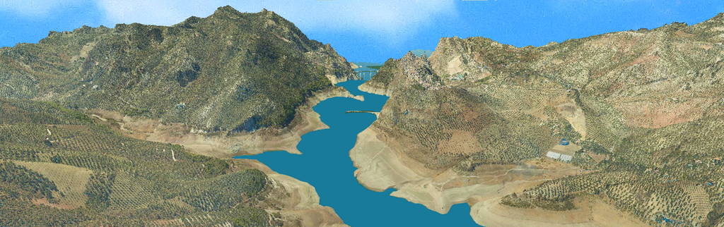

#### *gediDB examples*

Some examples to obtain GEDI pairs using the gediDB package developed by Besnard, Dombrowski, and Holcomb (2025) are presented [**here**](https://mdominguezd.github.io/cool_lit/test_gedidb.html).

## References

Besnard, Simon, Felix Dombrowski, and Amelia Holcomb. 2025. “gediDB.” Zenodo. https://doi.org/10.5281/zenodo.13885229.

Chen, Lin, Chunying Ren, Bai Zhang, Zongming Wang, Weidong Man, and Mingyue Liu. 2023. “Improved Object-Based Mapping of Aboveground Biomass Using Geographic Stratification with GEDI Data and Multi-Sensor Imagery.” *Remote Sensing* 15 (10): 2625–25. https://doi.org/10.3390/rs15102625.

Chen, Man, Wenquan Dong, Hao Yu, Iain Woodhouse, Casey M. Ryan, Haoyu Liu, Selena Georgiou, and Edward T. A. Mitchard. 2023. “Multimodal Deep Learning for Mapping Forest Dominant Height by Fusing GEDI with Earth Observation Data.” arXiv. https://doi.org/10.48550/arXiv.2311.11777.

East, Alyson, Andrew Hansen, Dolors Armenteras, Patrick Jantz, and David W. Roberts. 2023. “Measuring Understory Fire Effects from Space: Canopy Change in Response to Tropical Understory Fire and What This Means for Applications of GEDI to Tropical Forest Fire.” *Remote Sensing* 15 (3): 696. https://doi.org/10.3390/rs15030696.

Guerra-Hernández, Juan, José M. C. Pereira, Atticus Stovall, and Adrian Pascual. 2024. “Impact of Fire Severity on Forest Structure and Biomass Stocks Using NASA GEDI Data. Insights from the 2020 and 2021 Wildfire Season in Spain and Portugal.” *Science of Remote Sensing* 9 (June): 100134. https://doi.org/10.1016/j.srs.2024.100134.

Holcomb, Amelia, Patrick Burns, Srinivasan Keshav, and David A. Coomes. 2024. “Repeat GEDI Footprints Measure the Effects of Tropical Forest Disturbances.” *Remote Sensing of Environment* 308 (July): 114174. https://doi.org/10.1016/j.rse.2024.114174.

Huettermann, Sven, Simon Jones, Mariela Soto-Berelov, and Samuel Hislop. 2023. “Using Landsat Time Series and Bi-Temporal GEDI to Compare Spectral and Structural Vegetation Responses After Fire.” *International Journal of Applied Earth Observation and Geoinformation* 122 (August): 103403. https://doi.org/10.1016/j.jag.2023.103403.

Ji, Min, Huan Xie, Jürgen Oberst, Qi Xu, Yuan Sun, Sicong Liu, Changda Liu, and Xiaohua Tong. 2024. “Deforestation Detection from Spaceborne Full-Waveform Laser Altimetry, Incorporating Terrain Effects: A Case Study in Porto Velho, Brazil.” *International Journal of Applied Earth Observation and Geoinformation* 129 (May): 103861. https://doi.org/10.1016/j.jag.2024.103861.

Mandl, Lisa, Ana Stritih, Rupert Seidl, Christian Ginzler, and Cornelius Senf. 2023. “Spaceborne LiDAR for Characterizing Forest Structure Across Scales in the European Alps.” *Remote Sensing in Ecology and Conservation* 9 (5): 599–614. https://doi.org/10.1002/rse2.330.

Milenković, Milutin, Johannes Reiche, John Armston, Amy Neuenschwander, Wanda De Keersmaecker, Martin Herold, and Jan Verbesselt. 2022. “Assessing Amazon Rainforest Regrowth with GEDI and ICESat-2 Data.” *Science of Remote Sensing* 5 (June): 100051. https://doi.org/10.1016/j.srs.2022.100051.

Pronk, Maarten, Marieke Eleveld, and Hugo Ledoux. 2024. “Assessing Vertical Accuracy and Spatial Coverage of ICESat-2 and GEDI Spaceborne Lidar for Creating Global Terrain Models.” *Remote Sensing* 16 (13): 2259. https://doi.org/10.3390/rs16132259.

Schleich, Anouk, Sylvie Durrieu, Maxime Soma, and Cédric Vega. 2023. “Improving GEDI Footprint Geolocation Using a High-Resolution Digital Elevation Model.” *IEEE Journal of Selected Topics in Applied Earth Observations and Remote Sensing* 16: 7718–32. https://doi.org/10.1109/JSTARS.2023.3298991.

Urbazaev, Mikhail, Laura L. Hess, Steven Hancock, Luciane Yumie Sato, Jean Pierre Ometto, Christian Thiel, Clémence Dubois, et al. 2022. “Assessment of Terrain Elevation Estimates from ICESat-2 and GEDI Spaceborne LiDAR Missions Across Different Land Cover and Forest Types.” *Science of Remote Sensing* 6 (December): 100067. https://doi.org/10.1016/j.srs.2022.100067.